# CMPS Project M1

**Socioeconomic Effects of Air Quality Compliance: Milestone 1 Submission**

By Peter Carroll

Link to website: https://pcarroll16.github.io/index%20(3).html

**Project Overview**: This project aims to investigate potential relationships between air quality—specifically PM2.5 (Particulate Matter) levels—and employment metrics across U.S. states. The following data used are publicly available datasets from the EPA Air Quality System (AQS) and the Bureau of Labor Statistics (BLS). I will assess trends in both environmental and labor market data. We selected these datasets for their relevance, size, and public accessibility, with potential room for expansion to public health outcomes. The EPA’s dataset provides granular PM2.5 measurements at the county level, while the BLS data provides state-level employment figures, including total employment and average annual wages across industries. While the datasets differ in spatial resolution (state vs. county), they offer an opportunity to explore side-by-side trends and insights in the exploratory phase of this project. If time permits, I would like to examine specific county level trends overtime. Furthermore, I would like to examine which specific industries lead to the most particulate matter emissions. However, for this milestone 1 submission, I decided to look at trends on the state level.

Initial research question: How do trends in fine particulate matter (PM2.5) concentrations relate to economic indicators such as employment levels and average wages, speciifcally in manufacturing industries, across different U.S. states and counties?

### Focused Research Questions

- Are counties with higher PM2.5 levels more likely to have higher mortality from respiratory illness?
- Is there a difference in employment composition (e.g., manufacturing, mining) between high- and low-pollution counties?

### Data Sources

**Set Up**

```python
# Install necessary packages and libraries
!pip install xlrd
import pandas as pd
import numpy as np
import matplotlib.pyplot as plt
import seaborn as sns

# Mount Drive
from google.colab import drive
drive.mount('/content/drive')
```

```python
# Load datasets from Google Drive
pm25_path = '/content/drive/MyDrive/CMPS Project Data/annual_conc_by_monitor_2018.csv'
bls_path = '/content/drive/MyDrive/CMPS Project Data/state_M2018_dl.xlsx'

df_pm25 = pd.read_csv(pm25_path)
df_bls_state = pd.read_excel(bls_path, skiprows=4)
```

```python
death_path = '/content/drive/MyDrive/CMPS Project Data/Death Causes 2018 resp.xlsx'
df_death = pd.read_excel(death_path)
```

```python
#County stats
cpath_1 = '/content/drive/MyDrive/CMPS Project Data/County Deaths nervous.xlsx'
cpath_2 = '/content/drive/MyDrive/CMPS Project Data/County Deaths immune.xlsx'
cpath_3 = '/content/drive/MyDrive/CMPS Project Data/County Deaths resp.xlsx'

nerv_df = pd.read_excel(cpath_1)
immune_df = pd.read_excel(cpath_2)
resp_df = pd.read_excel(cpath_3)
```

```python
industry_path = '/content/drive/MyDrive/CMPS Project Data/County Industry.csv'
industry_county = pd.read_csv(industry_path, header = 1)
industry_county.head()
```

|  | Geography | Geographic Area Name | Estimate!!Total | Margin of Error!!Total | Estimate!!Total!!Male | Margin of Error!!Total!!Male | Estimate!!Total!!Male!!Agriculture, forestry, fishing and hunting, and mining | Margin of Error!!Total!!Male!!Agriculture, forestry, fishing and hunting, and mining | Estimate!!Total!!Male!!Agriculture, forestry, fishing and hunting, and mining!!Agriculture, forestry, fishing and hunting | Margin of Error!!Total!!Male!!Agriculture, forestry, fishing and hunting, and mining!!Agriculture, forestry, fishing and hunting | ... | Margin of Error!!Total!!Female!!Arts, entertainment, and recreation, and accommodation and food services | Estimate!!Total!!Female!!Arts, entertainment, and recreation, and accommodation and food services!!Arts, entertainment, and recreation | Margin of Error!!Total!!Female!!Arts, entertainment, and recreation, and accommodation and food services!!Arts, entertainment, and recreation | Estimate!!Total!!Female!!Arts, entertainment, and recreation, and accommodation and food services!!Accommodation and food services | Margin of Error!!Total!!Female!!Arts, entertainment, and recreation, and accommodation and food services!!Accommodation and food services | Estimate!!Total!!Female!!Other services, except public administration | Margin of Error!!Total!!Female!!Other services, except public administration | Estimate!!Total!!Female!!Public administration | Margin of Error!!Total!!Female!!Public administration | Unnamed: 112 |
| --- | --- | --- | --- | --- | --- | --- | --- | --- | --- | --- | --- | --- | --- | --- | --- | --- | --- | --- | --- | --- | --- |
| 0 | 0500000US01003 | Baldwin County, Alabama | 102800.0 | 4327.0 | 50739.0 | 2779.0 | 957.0 | 642.0 | 509.0 | 391.0 | ... | 1655.0 | 1228.0 | 614.0 | 6318.0 | 1661.0 | 3281.0 | 1154.0 | 2015.0 | 722.0 | NaN |
| 1 | 0500000US01015 | Calhoun County, Alabama | 49415.0 | 3039.0 | 25878.0 | 1907.0 | 382.0 | 491.0 | 333.0 | 485.0 | ... | 1026.0 | 278.0 | 323.0 | 2350.0 | 860.0 | 1644.0 | 762.0 | 1239.0 | 538.0 | NaN |
| 2 | 0500000US01043 | Cullman County, Alabama | 35876.0 | 1979.0 | 19369.0 | 1284.0 | 418.0 | 298.0 | 246.0 | 205.0 | ... | 779.0 | 468.0 | 395.0 | 1838.0 | 749.0 | 853.0 | 418.0 | 106.0 | 120.0 | NaN |
| 3 | 0500000US01049 | DeKalb County, Alabama | 29616.0 | 2399.0 | 15878.0 | 1434.0 | 614.0 | 412.0 | 614.0 | 412.0 | ... | 672.0 | 75.0 | 127.0 | 1538.0 | 637.0 | 1479.0 | 752.0 | 165.0 | 169.0 | NaN |
| 4 | 0500000US01051 | Elmore County, Alabama | 34265.0 | 2312.0 | 16640.0 | 1538.0 | 609.0 | 434.0 | 328.0 | 326.0 | ... | 782.0 | 712.0 | 617.0 | 1536.0 | 542.0 | 1122.0 | 662.0 | 1854.0 | 837.0 | NaN |

5 rows × 113 columns

Data Cleaning- County Level data

```python
print(industry_county.columns.tolist())
```

```
['Geography', 'Geographic Area Name', 'Estimate!!Total', 'Margin of Error!!Total', 'Estimate!!Total!!Male', 'Margin of Error!!Total!!Male', 'Estimate!!Total!!Male!!Agriculture, forestry, fishing and hunting, and mining', 'Margin of Error!!Total!!Male!!Agriculture, forestry, fishing and hunting, and …
```

```python
# Drop margin of error columns
industry_county = industry_county[[col for col in industry_county.columns if not col.startswith("Margin of Error")]]
# Remove everything before the last '!!' and strip
industry_county.columns = [col.split('!!')[-1].strip() for col in industry_county.columns]


industry_county.head()
```

|  | Geography | Geographic Area Name | Total | Male | Agriculture, forestry, fishing and hunting, and mining | Agriculture, forestry, fishing and hunting | Mining, quarrying, and oil and gas extraction | Construction | Manufacturing | Wholesale trade | ... | Administrative and support and waste management services | Educational services, and health care and social assistance | Educational services | Health care and social assistance | Arts, entertainment, and recreation, and accommodation and food services | Arts, entertainment, and recreation | Accommodation and food services | Other services, except public administration | Public administration | Unnamed: 112 |
| --- | --- | --- | --- | --- | --- | --- | --- | --- | --- | --- | --- | --- | --- | --- | --- | --- | --- | --- | --- | --- | --- |
| 0 | 0500000US01003 | Baldwin County, Alabama | 102800.0 | 50739.0 | 957.0 | 509.0 | 448.0 | 9535.0 | 6225.0 | 1858.0 | ... | 3060.0 | 15077.0 | 4920.0 | 10157.0 | 7546.0 | 1228.0 | 6318.0 | 3281.0 | 2015.0 | NaN |
| 1 | 0500000US01015 | Calhoun County, Alabama | 49415.0 | 25878.0 | 382.0 | 333.0 | 49.0 | 3112.0 | 6285.0 | 979.0 | ... | 804.0 | 7690.0 | 3178.0 | 4512.0 | 2628.0 | 278.0 | 2350.0 | 1644.0 | 1239.0 | NaN |
| 2 | 0500000US01043 | Cullman County, Alabama | 35876.0 | 19369.0 | 418.0 | 246.0 | 172.0 | 3654.0 | 4668.0 | 796.0 | ... | 163.0 | 5802.0 | 1237.0 | 4565.0 | 2306.0 | 468.0 | 1838.0 | 853.0 | 106.0 | NaN |
| 3 | 0500000US01049 | DeKalb County, Alabama | 29616.0 | 15878.0 | 614.0 | 614.0 | 0.0 | 2246.0 | 6193.0 | 117.0 | ... | 200.0 | 3892.0 | 1452.0 | 2440.0 | 1613.0 | 75.0 | 1538.0 | 1479.0 | 165.0 | NaN |
| 4 | 0500000US01051 | Elmore County, Alabama | 34265.0 | 16640.0 | 609.0 | 328.0 | 281.0 | 3402.0 | 2428.0 | 498.0 | ... | 199.0 | 6754.0 | 2414.0 | 4340.0 | 2248.0 | 712.0 | 1536.0 | 1122.0 | 1854.0 | NaN |

5 rows × 58 columns

```python
# Clean and standardize death data
def clean_death_data(df, system_name):
    # Drop any rows with missing or non-numeric death counts
    df = df.copy()
    df = df[df['Deaths'].notna()]
    df = df[~df['Deaths'].isin(['Suppressed', 'Unreliable'])]

    # Convert columns to numeric
    df['Deaths'] = pd.to_numeric(df['Deaths'], errors='coerce')
    df['Population'] = pd.to_numeric(df['Population'], errors='coerce')
    df['Crude Rate'] = pd.to_numeric(df['Crude Rate'], errors='coerce')

    # Create label to distinguish death type
    df['System'] = system_name

    # Keep only needed columns
    df = df[['County Code', 'County', 'Year', 'Cause of death', 'Deaths', 'Population', 'Crude Rate', 'System']]
    return df

# Clean each dataset
nerv_clean = clean_death_data(nerv_df, 'Nervous')
immune_clean = clean_death_data(immune_df, 'Immune')
resp_clean = clean_death_data(resp_df, 'Respiratory')

# Concatenate into a single dataframe
all_deaths = pd.concat([nerv_clean, immune_clean, resp_clean], ignore_index=True)

# Check the result
all_deaths.head()
```

|  | County Code | County | Year | Cause of death | Deaths | Population | Crude Rate | System |
| --- | --- | --- | --- | --- | --- | --- | --- | --- |
| 0 | 1001.0 | Autauga County, AL | 2018.0 | Alzheimer disease, unspecified | 29.0 | 55601.0 | 52.2 | Nervous |
| 1 | 1003.0 | Baldwin County, AL | 2018.0 | Parkinson disease | 24.0 | 218022.0 | 11.0 | Nervous |
| 2 | 1003.0 | Baldwin County, AL | 2018.0 | Alzheimer disease, unspecified | 83.0 | 218022.0 | 38.1 | Nervous |
| 3 | 1003.0 | Baldwin County, AL | 2018.0 | Senile degeneration of brain, not elsewhere cl... | 35.0 | 218022.0 | 16.1 | Nervous |
| 4 | 1003.0 | Baldwin County, AL | 2018.0 | Anoxic brain damage, not elsewhere classified | 12.0 | 218022.0 | NaN | Nervous |

**Data Cleaning- BLS**

```python
# Clean BLS data
#Rename columns for clarity
df_bls_state.columns = [
    'state_code', 'state_abbr', 'state_name', 'occupation_code', 'occupation_title',
    'level', 'employment', 'employment_RSE', 'emp_per_1000_jobs', 'location_quotient',
    'median_hourly_wage', 'mean_hourly_wage', 'annual_mean_wage', 'percentile_10_hourly',
    'percentile_25_hourly', 'percentile_50_hourly', 'percentile_75_hourly', 'percentile_90_hourly',
    'annual_10th', 'annual_25th', 'annual_median', 'annual_75th', 'annual_90th', 'footnote_1', 'footnote_2'
]

# Clean numeric columns
for col in ['employment', 'annual_mean_wage']:
    df_bls_state[col] = df_bls_state[col].replace(['*', '**', '#'], pd.NA)
    df_bls_state[col] = df_bls_state[col].astype(str).str.replace(',', '', regex=False)
    df_bls_state[col] = pd.to_numeric(df_bls_state[col], errors='coerce')

# Filter for manufacturing-related occupations
manufacturing_keywords = ['Production', 'Plant', 'Industrial', 'Machinist', 'Assembler', 'Machine', 'Operator']
df_mfg = df_bls_state[
    df_bls_state['occupation_title'].str.contains('|'.join(manufacturing_keywords), case=False, na=False)
]

df_mfg = df_mfg.dropna(subset=['employment', 'annual_mean_wage'])
```

```python
# Aggregate manufacturing employment by state
df_mfg_agg = df_mfg.groupby('state_name').agg({
    'employment': 'sum',
    'annual_mean_wage': 'mean'
}).reset_index()
```

```python
df_mfg.head()
```

|  | state_code | state_abbr | state_name | occupation_code | occupation_title | level | employment | employment_RSE | emp_per_1000_jobs | location_quotient | ... | percentile_50_hourly | percentile_75_hourly | percentile_90_hourly | annual_10th | annual_25th | annual_median | annual_75th | annual_90th | footnote_1 | footnote_2 |
| --- | --- | --- | --- | --- | --- | --- | --- | --- | --- | --- | --- | --- | --- | --- | --- | --- | --- | --- | --- | --- | --- |
| 8 | 1 | AL | Alabama | 11-3051 | Industrial Production Managers | detailed | 3530.0 | 4 | 1.817 | 1.45 | ... | 46.52 | 59.23 | 76.03 | 60030 | 76330 | 96770 | 123200 | 158150 | NaN | NaN |
| 89 | 1 | AL | Alabama | 17-2112 | Industrial Engineers | detailed | 5630.0 | 2.9 | 2.897 | 1.5 | ... | 40.65 | 49.66 | 61.12 | 55230 | 68780 | 84540 | 103290 | 127130 | NaN | NaN |
| 106 | 1 | AL | Alabama | 17-3026 | Industrial Engineering Technicians | detailed | 1030.0 | 9 | 0.528 | 1.15 | ... | 25 | 31.45 | 38.14 | 33130 | 41650 | 52010 | 65410 | 79330 | NaN | NaN |
| 112 | 1 | AL | Alabama | 19-1013 | Soil and Plant Scientists | detailed | 50.0 | 5.7 | 0.025 | 0.24 | ... | 27.01 | 37.29 | 46.19 | 37880 | 44770 | 56180 | 77560 | 96080 | NaN | NaN |
| 236 | 1 | AL | Alabama | 27-1021 | Commercial and Industrial Designers | detailed | 180.0 | 7.9 | 0.092 | 0.4 | ... | 30.85 | 39.52 | 46.63 | 34020 | 51000 | 64170 | 82200 | 97000 | NaN | NaN |

5 rows × 25 columns

```python
# Basic statistics
df_mfg[['employment', 'annual_mean_wage']].describe()
```

|  | employment | annual_mean_wage |
| --- | --- | --- |
| count | 4036.000000 | 4036.000000 |
| mean | 4655.686323 | 3.805649 |
| std | 28621.403597 | 2.436501 |
| min | 30.000000 | 0.400000 |
| 25% | 220.000000 | 2.200000 |
| 50% | 670.000000 | 3.200000 |
| 75% | 2140.000000 | 4.700000 |
| max | 836260.000000 | 28.000000 |

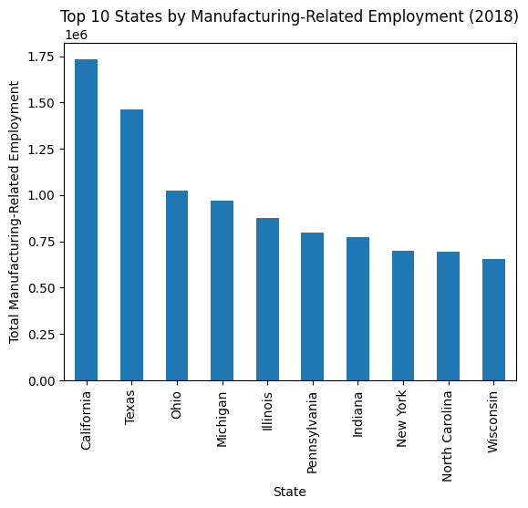

```python
# Bar plot for manufacturing by state
df_state_agg = df_mfg_agg.groupby('state_name')['employment'].sum().dropna().sort_values(ascending=False).head(10)

df_state_agg.plot(kind='bar')
plt.ylabel('Total Manufacturing-Related Employment')
plt.xlabel('State')
plt.title('Top 10 States by Manufacturing-Related Employment (2018)')
plt.show()
```

**PM2.5 Cleaning and EDA**

```python
# Clean PM2.5 data
df_pm25_clean = df_pm25[df_pm25['Parameter Name'] == 'PM2.5 - Local Conditions']
df_pm25_clean = df_pm25_clean[['State Name', 'Arithmetic Mean']].dropna()
```

```python
# Aggregate PM2.5 by state (mean concentration)
df_pm25_agg = df_pm25_clean.groupby('State Name')['Arithmetic Mean'].mean().reset_index()
df_pm25_agg.columns = ['state_name', 'avg_pm25']

df_pm25_agg.head()
```

|  | state_name | avg_pm25 |
| --- | --- | --- |
| 0 | Alabama | 8.517442 |
| 1 | Alaska | 7.966343 |
| 2 | Arizona | 7.948104 |
| 3 | Arkansas | 8.780321 |
| 4 | California | 10.470187 |

```python
# Merge Datasets
df_merged = pd.merge(df_mfg_agg, df_pm25_agg, on='state_name', how='inner')

df_merged.head()
```

|  | state_name | employment | annual_mean_wage | avg_pm25 |
| --- | --- | --- | --- | --- |
| 0 | Alabama | 430410.0 | 3.841304 | 8.517442 |
| 1 | Alaska | 22660.0 | 5.372093 | 7.966343 |
| 2 | Arizona | 238640.0 | 3.864557 | 7.948104 |
| 3 | Arkansas | 231890.0 | 3.965854 | 8.780321 |
| 4 | California | 1732940.0 | 2.974227 | 10.470187 |

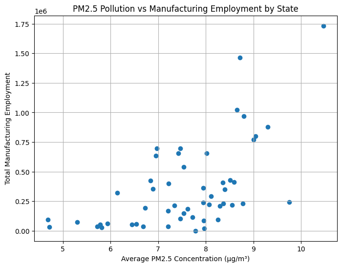

|  | avg_pm25 | employment | annual_mean_wage |
| --- | --- | --- | --- |
| avg_pm25 | 1.000000 | 0.574466 | -0.204259 |
| employment | 0.574466 | 1.000000 | -0.602805 |
| annual_mean_wage | -0.204259 | -0.602805 | 1.000000 |

```python
# Scatter plot: PM2.5 vs Manufacturing Employment
plt.figure(figsize=(8,6))
plt.scatter(df_merged['avg_pm25'], df_merged['employment'])
plt.xlabel('Average PM2.5 Concentration (µg/m³)')
plt.ylabel('Total Manufacturing Employment')
plt.title('PM2.5 Pollution vs Manufacturing Employment by State')
plt.grid(True)
plt.show()

# Correlation matrix
df_merged[['avg_pm25', 'employment', 'annual_mean_wage']].corr()
```

EDA using BLS data to see pm2.5 output for production jobs

```python
# Filter and summarize BLS by state and industry to see how certain industries correlate to pm2.5 output for later analysis
# Based on the available columns, I am using 'state_name' and occupation_title to filter. you can modify it to other columns if needed
df_bls_filtered = df_bls_state[(df_bls_state['state_name'] != 'District of Columbia') & (df_bls_state['occupation_title'].str.contains('Production', case=False))]
df_bls_grouped = df_bls_filtered.groupby(['state_name', 'occupation_title'])[['employment', 'annual_mean_wage']].sum().reset_index()

# Merge state PM2.5 with employment data
df_merged = df_bls_grouped.merge(df_pm25_state, left_on='state_name', right_on='State Name', how='left')
df_merged['PM2.5 per job'] = df_merged['Arithmetic Mean'] / df_merged['employment']
df_merged = df_merged.dropna(subset=['PM2.5 per job'])

# Summary table
df_merged_sorted = df_merged.sort_values(by='PM2.5 per job', ascending=False)
df_merged_sorted[['state_name', 'occupation_title', 'PM2.5 per job']].head(10)
```

|  | state_name | occupation_title | PM2.5 per job |
| --- | --- | --- | --- |
| 281 | Virgin Islands | Production, Planning, and Expediting Clerks | 0.194725 |
| 279 | Virgin Islands | First-Line Supervisors of Production and Opera... | 0.059915 |
| 242 | Rhode Island | Production Workers, All Other | 0.058663 |
| 8 | Alaska | Industrial Production Managers | 0.049790 |
| 156 | Montana | Industrial Production Managers | 0.047787 |
| 68 | Hawaii | Production Workers, All Other | 0.044690 |
| 158 | Montana | Production Workers, All Other | 0.041814 |
| 155 | Montana | Helpers--Production Workers | 0.041814 |
| 310 | Wyoming | Production Workers, All Other | 0.039285 |
| 10 | Alaska | Production Workers, All Other | 0.034636 |

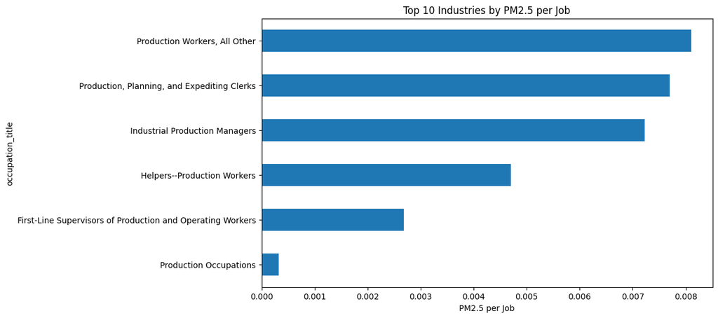

```python
#PLot
top_industries = df_merged_sorted.groupby('occupation_title')['PM2.5 per job'].mean().sort_values(ascending=False).head(10)
top_industries.plot(kind='barh', figsize=(10,6), title='Top 10 Industries by PM2.5 per Job')
plt.xlabel('PM2.5 per Job')
plt.gca().invert_yaxis()
plt.show()
```

Now, lets begin analysis on a county level. This will be the meat of the project- the stuff before was mostly exploratory. I believe meaningful results wil have to be derived on the county analysis level

```python
# Clean county name function
def clean_county(name):
    if pd.isna(name):
        return None
    name = str(name).split(',')[0]  # Take "Alachua" from "Alachua, FL"
    name = name.replace(" County", "").replace(" Parish", "").lower().strip()
    return name

death_avg_pivot['County_clean'] = death_avg_pivot['County'].apply(clean_county)
df_pm25_clean['County_clean'] = df_pm25_clean['County Name'].apply(clean_county)

# look for matches
shared_counties = set(death_avg_pivot['County_clean']).intersection(df_pm25_clean['County_clean'])
print(f"✅ Common cleaned counties: {len(shared_counties)}")

#Group by cleaned county
pm25_grouped = df_pm25_clean.groupby('County_clean')['Arithmetic Mean'].mean().reset_index()
pm25_grouped = pm25_grouped.rename(columns={'Arithmetic Mean': 'PM25'})

#prep for merge
death_avg_pivot_clean = death_avg_pivot.drop(columns='County').rename(columns={'County_clean': 'County'})
death_avg_pivot_clean = death_avg_pivot_clean.rename(columns={'County_clean': 'County'})
pm25_grouped = pm25_grouped.rename(columns={'County_clean': 'County'})

# Merge deaths and PM2.5 by cleaned county name
merged = pd.merge(death_avg_pivot_clean, pm25_grouped, on='County', how='inner')

# Summary statistics
print(merged[['PM25', 'Nervous', 'Immune', 'Respiratory']].describe())
```

```
✅ Common cleaned counties: 444
             PM25     Nervous    Immune  Respiratory
count  800.000000  646.000000  4.000000   757.000000
mean     8.060243   36.885979  0.837500    42.232305
std      1.820485   23.537082  0.734138    29.041105
min      2.565076    3.300000  0.300000     2.920000
25%      7.145833   18.837500  0.375000    17.675000
50%      7.896841   31.650000  0.575000    36.900000
75%      8.753887   50.625000  1.037500    61.600000
max     18.767521  150.000000  1.900000   156.600000
```

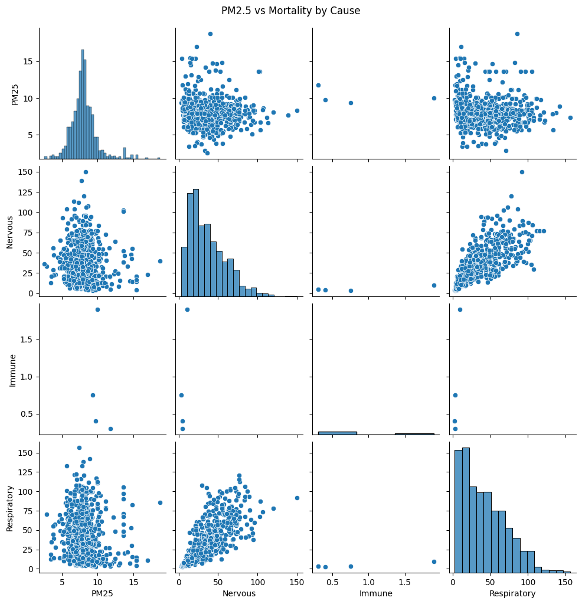

```python
# Plots
sns.pairplot(merged[['PM25', 'Nervous', 'Immune', 'Respiratory']])
plt.suptitle("PM2.5 vs Mortality by Cause", y=1.02)
plt.show()
```

Now, bring in economic data

```python
print("Sample county names in merged:")
print(merged['County'].unique()[:10])

print("\nSample county names in industry_county:")
print(industry_county['County'].unique()[:10])
```

```
Sample county names in merged:
['ada' 'adams' 'alachua' 'alameda' 'albany' 'albemarle' 'allegan'
 'allegheny' 'allen' 'androscoggin']

Sample county names in industry_county:
['Baldwin, Alabama' 'Calhoun, Alabama' 'Cullman, Alabama'
 'DeKalb, Alabama' 'Elmore, Alabama' 'Etowah, Alabama' 'Houston, Alabama'
 'Jefferson, Alabama' 'Lauderdale, Alabama' 'Lee, Alabama']
```

```python
# Standardize county names in both datasets
def standardize_county_names(series):
    return (
        series.str.replace(r' County| Parish| city', '', regex=True)
              .str.split(',').str[0]
              .str.strip()
              .str.lower()
    )

# Apply to both datasets
merged_with_industry['County_clean'] = standardize_county_names(merged_with_industry['County_clean'])
industry_county['County_clean'] = standardize_county_names(industry_county['County'])

# Check matches
merged_names = set(merged_with_industry['County_clean'].unique())
industry_names = set(industry_county['County_clean'].unique())
common = merged_names.intersection(industry_names)
print(f"✅ Matching counties: {len(common)}")

# Subset industry data to only needed columns
industry_sub = industry_county.drop(columns=['County', 'Geography'], errors='ignore')
```

[output not shown]

[output not shown]

[output not shown]

```python
# Merge
final_merged = pd.merge(
    merged_with_industry,
    industry_sub,
    on='County_clean',
    how='inner'
)

display(final_merged.head())



# Look for missing
missing = final_merged.isna().sum().sort_values(ascending=False)
print("Top missing columns:\n", missing.head(10))
```

|  | Immune | Nervous | Respiratory | County_x | PM25 | County_clean | Geography | County_y | Total_x | Male_x | ... | Management of companies and enterprises_y | Administrative and support and waste management services_y | Educational services, and health care and social assistance_y | Educational services_y | Health care and social assistance_y | Arts, entertainment, and recreation, and accommodation and food services_y | Arts, entertainment, and recreation_y | Accommodation and food services_y | Other services, except public administration_y | Public administration_y |
| --- | --- | --- | --- | --- | --- | --- | --- | --- | --- | --- | --- | --- | --- | --- | --- | --- | --- | --- | --- | --- | --- |
| 0 | NaN | 18.90 | 17.45 | ada | 7.154295 | ada | NaN | NaN | NaN | NaN | ... | 44.0 | 4034.0 | 39379.0 | 14349.0 | 25030.0 | 11282.0 | 1934.0 | 9348.0 | 6704.0 | 4898.0 |
| 1 | NaN | 15.35 | 10.68 | adams | 9.690895 | adams | NaN | NaN | NaN | NaN | ... | 409.0 | 5524.0 | 37888.0 | 13668.0 | 24220.0 | 12640.0 | 2169.0 | 10471.0 | 5530.0 | 5132.0 |
| 2 | NaN | 15.35 | 10.68 | adams | 9.690895 | adams | NaN | NaN | NaN | NaN | ... | 0.0 | 243.0 | 6520.0 | 2036.0 | 4484.0 | 1867.0 | 504.0 | 1363.0 | 527.0 | 475.0 |
| 3 | NaN | 15.35 | 10.68 | adams | 9.690895 | adams | NaN | NaN | NaN | NaN | ... | 31.0 | 587.0 | 9597.0 | 3323.0 | 6274.0 | 1799.0 | 252.0 | 1547.0 | 1404.0 | 752.0 |
| 4 | NaN | 73.10 | 56.30 | adams | 9.690895 | adams | NaN | NaN | NaN | NaN | ... | 409.0 | 5524.0 | 37888.0 | 13668.0 | 24220.0 | 12640.0 | 2169.0 | 10471.0 | 5530.0 | 5132.0 |

5 rows × 118 columns

```
Top missing columns:
 Agriculture, forestry, fishing and hunting_x                1780
Agriculture, forestry, fishing and hunting, and mining_x    1780
Male_x                                                      1780
Total_x                                                     1780
County_y                                                    1780
Geography                                                   1780
Manufacturing_x                                             1780
Wholesale trade_x                                           1780
Retail trade_x                                              1780
Transportation and warehousing, and utilities_x             1780
dtype: int64
```

```python
# Function to deduplicate column names
def deduplicate_columns(df):
    seen = {}
    new_cols = []
    for col in df.columns:
        if col not in seen:
            seen[col] = 1
            new_cols.append(col)
        else:
            seen[col] += 1
            new_cols.append(f"{col}.{seen[col]}")
    df.columns = new_cols
    return df

# Remove duplicates
final_merged = deduplicate_columns(final_merged)
```

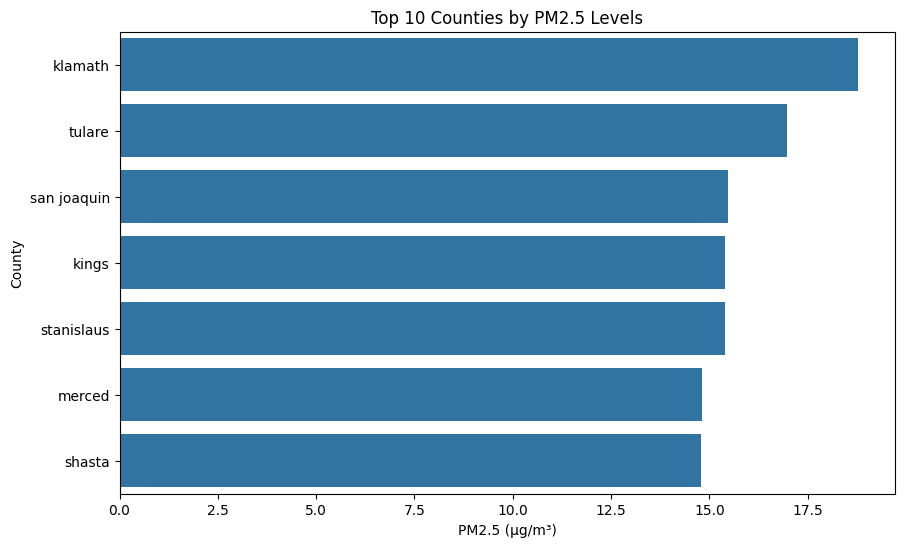

```python
# Do some eda- look at top pollutants by county
top_polluters = final_merged.sort_values(by='PM25', ascending=False).head(10)
plt.figure(figsize=(10, 6))
sns.barplot(data=top_polluters, x='PM25', y='County_clean')
plt.title("Top 10 Counties by PM2.5 Levels")
plt.xlabel("PM2.5 (µg/m³)")
plt.ylabel("County")
plt.show()
```

```python
#Standardize
final_merged['mfg_jobs_per_1k'] = final_merged['Manufacturing_y'] / final_merged['Total_y'] * 1000
```

```python
# List of industry employment columns
industry_cols = [
    'Manufacturing_y',
    'Construction_y',
    'Transportation and warehousing, and utilities_y',
    'Wholesale trade_y',
    'Retail trade_y'
]

# Standardize
for col in industry_cols:
    new_col = col.replace('_y', '_per_1k')
    final_merged[new_col] = final_merged[col] / final_merged['Total_y'] * 1000

# Display the new columns
final_merged[[col.replace('_y', '_per_1k') for col in industry_cols]].describe()

# New list
per_1k_cols = [col.replace('_y', '_per_1k') for col in industry_cols]
```

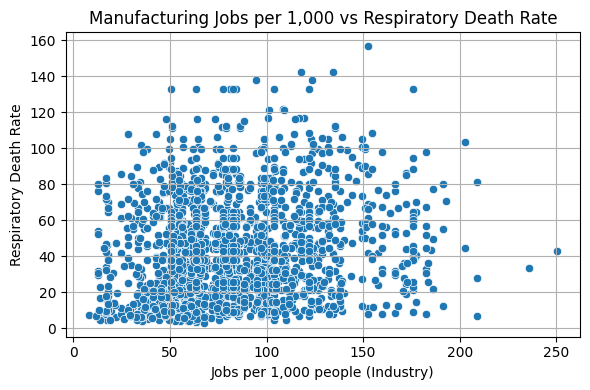

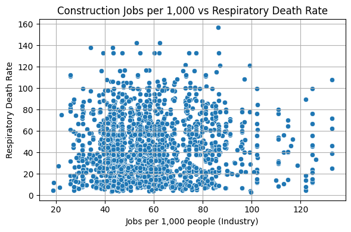

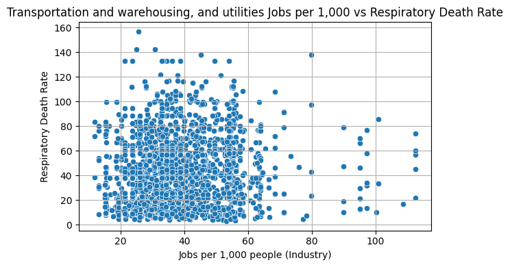

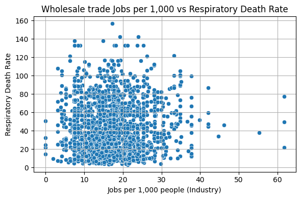

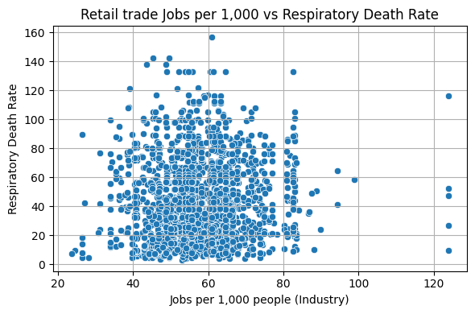

```python
# Plot employment vs respiratory death rate
for col in per_1k_cols:
    if col in final_merged.columns:
        plt.figure(figsize=(6, 4))
        sns.scatterplot(data=final_merged, x=col, y='Respiratory')
        plt.title(f'{col.replace("_per_1k", "")} Jobs per 1,000 vs Respiratory Death Rate')
        plt.xlabel('Jobs per 1,000 people (Industry)')
        plt.ylabel('Respiratory Death Rate')
        plt.grid(True)
        plt.tight_layout()
        plt.show()
```

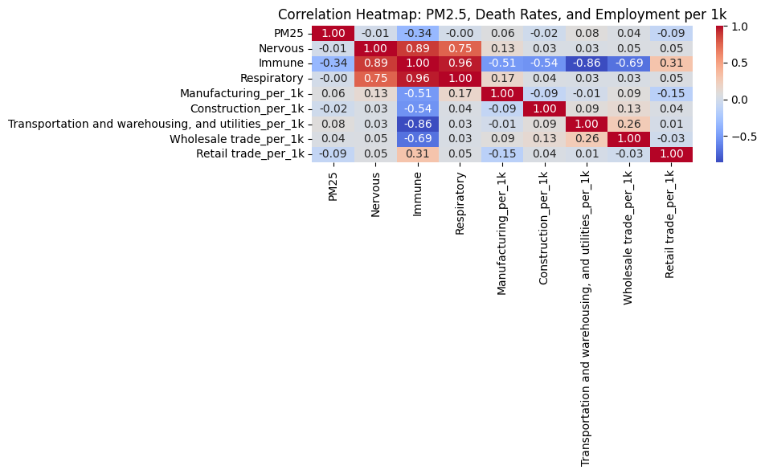

```python
# Heatmap
heatmap_vars = [
    'PM25',
    'Nervous',
    'Immune',
    'Respiratory',
    'Manufacturing_per_1k',
    'Construction_per_1k',
    'Transportation and warehousing, and utilities_per_1k',
    'Wholesale trade_per_1k',
    'Retail trade_per_1k'
]

# Filter to only existing ones
existing_vars = [col for col in heatmap_vars if col in final_merged.columns]

# Generate heatmap
plt.figure(figsize=(10, 6))
sns.heatmap(final_merged[existing_vars].corr(), annot=True, cmap='coolwarm', fmt='.2f')
plt.title('Correlation Heatmap: PM2.5, Death Rates, and Employment per 1k')
plt.tight_layout()
plt.show()
```

**Summary and Next Steps**

This analysis explored relationships between PM2.5 pollution, death rates from respiratory, immune, and nervous system conditions, and county-level industrial employment. While PM2.5 levels show weak or no direct correlation with death rates, death rates among the three disease categories are strongly positively correlated, especially between respiratory and immune deaths. Additionally, counties with higher per-capita employment in manufacturing, construction, and transportation do not show a strong linear relationship with death rates, though some industries like manufacturing have a wider spread of associated death rates, indicating potential heterogeneous local effects.

Two Potential Modeling Approaches

1. Predictive Model of Respiratory Mortality

Goal: Predict county-level respiratory death rates using PM2.5 levels and industry job concentrations.

Approach: Use multiple linear regression or a tree-based model to explore how environmental and economic factors together predict mortality outcomes.

Insight: Identify which factors most strongly predict respiratory health burdens.

2. Causal Inference Model of Pollution Exposure

Goal: Assess whether counties with higher pollution levels and greater industrial employment experience disproportionately higher respiratory death rates.

Approach: Consider using a regression or matching-based method to test whether pollution’s impact on mortality is conditional on the presence of heavy industry.

Insight: Explore whether pollution-related deaths are amplified in industrial regions due to occupational or socioeconomic vulnerabilities.

```python
%%shell
jupyter nbconvert --to html "/content/drive/MyDrive/Colab Notebooks/CMPS Project M1.ipynb"
```

```
[NbConvertApp] Converting notebook /content/drive/MyDrive/Colab Notebooks/CMPS Project M1.ipynb to html
[NbConvertApp] WARNING | Alternative text is missing on 3 image(s).
[NbConvertApp] Writing 562679 bytes to /content/drive/MyDrive/Colab Notebooks/CMPS Project M1.html
```